# Đồ án kết thúc học phần

22110012 - Hữu Ân 22110059 - Hồng Hiên

01-07-2025

## Giới thiệu:

Tập tin “VNL2023.csv” là bộ dữ liệu về các cầu thủ bóng chuyền trong Giải bóng chuyền quốc gia năm 2023 (Volleyball National League in 2023), được lấy từ Kaggle

https://www.kaggle.com/datasets/yeganehbavafa/vnl-men-2023.

Bộ dữ gồm 131 quan trắc và 10 biến sau:

1. Player: Tên của vận động viên
2. Country: Quốc tịch của vận động viên
3. Age: Tuổi của vận động viên
4. Attack: Trung bình tổng thể của vận động viên trong mỗi trận đấu khi tham gia khâu tấn công
5. Block (Chắn bóng): Trung bình tổng thể của vận động viên trong mỗi trận đấu khi tham gia phòng thủ trên lưới
6. Serve (Phát bóng): Trung bình khả năng phát bóng của từng vận động viên trong trận đấu
7. Set (Chuyền bóng): Trung bình số lần chuyền thành công, lỗi chuyền và số lần chuyền thử trong mỗi pha bóng
8. Dig (Phòng thủ): Trung bình số lần cứu bóng, lỗi cứu bóng và đỡ bóng từ đối phương tấn công
9. Receive (Đỡ bóng): Trung bình của các lần chạm được bóng khi phòng thủ thành công và pha bóng vẫn còn tiếp tục
10. Position (Vị trí): Vị trí đại diện cho vị trí chơi của vận động viên và bao gồm 5 vị trí cơ bản sau đây

    – OH (Outside Hitter): Chủ công ngoài

    – OP (Opposite): Đối chuyền

    – MB (Middle Blocker): Trung phong chắn bóng

    – S (Setter): Chuyền hai

    – L (Libero): cầu thủ chuyên phòng thủ

## Vấn đề nghiên cứu:

“Phân tích sự khác biệt về hiệu suất thi đấu giữa các vị trí (Position) trong bóng chuyền nam VNL 2023 và xác định các yếu tố chính ảnh hưởng đến hiệu suất của từng vị trí.”

## Lý do chọn đề tài:

### Tính ứng dụng cao:

- Huấn luyện viên có thể tối ưu hóa chiến thuật dựa trên điểm mạnh/yếu của từng vị trí.
- Cầu thủ trẻ có thể định hướng tập trung vào kỹ năng quan trọng nhất cho vị trí của mình.

### Phù hợp phương pháp đa biến:

- Có thể kết hợp MANOVA (so sánh nhiều biến hiệu suất giữa các nhóm) và PCA (rút gọn biến để tìm yếu tố chính).

## Phương pháp triển khai:

### Bước 2: PCA

- Chuẩn hóa dữ liệu $\to$ Phân tích thành phần chính $\to$ Chọn số thành phần dựa trên scree plot hoặc eigenvalue > 1.
- Diễn giải thành phần dựa trên factor loadings (|loading| > 0.5).
- Vẽ biplot để trực quan hóa mối quan hệ giữa cầu thủ, vị trí và thành phần.

### Bước 3: K-means clustering

- K-means clustering trên các thành phần PCA để phát hiện nhóm cầu thủ tiềm năng.

## Nhập dữ liệu:

```r
vnl_data <- read.csv("VNL2023.csv", header = TRUE, stringsAsFactors = FALSE)
head(vnl_data)
```

```
##                Player   Country Age Attack Block Serve  Set  Dig Receive
## 1       Ichikawa Yuki     Japan  28  15.80  1.13  1.40 0.07 4.80    5.60
## 2         Romano Yuri     Italy  26  12.33  1.07  1.47 0.00 3.87    0.00
## 3    Abdel-Aziz Nimir Nederland  31  15.33  0.67  2.08 0.00 3.17    0.25
## 4 Herrera Jaime Jesus      Cuba  28  15.00  0.92  1.75 0.00 3.33    0.17
## 5       Takahashi Ran     Japan  22  11.53  0.67  1.00 0.07 6.40    5.07
## 6      Luburic Drazen    Serbia  30  14.33  0.58  1.08 0.00 4.25    0.00
##   Position
## 1       OH
## 2       OP
## 3       OP
## 4       OP
## 5       OH
## 6       OP
```

```r
str(vnl_data)
```

```
## 'data.frame':    131 obs. of  10 variables:
##  $ Player  : chr  "Ichikawa Yuki" "Romano Yuri" "Abdel-Aziz Nimir" "Herrera Jaime Jesus" ...
##  $ Country : chr  "Japan" "Italy" "Nederland" "Cuba" ...
##  $ Age     : int  28 26 31 28 22 30 35 24 29 31 ...
##  $ Attack  : num  15.8 12.3 15.3 15 11.5 ...
##  $ Block   : num  1.13 1.07 0.67 0.92 0.67 0.58 0.31 1.83 0.62 0.92 ...
##  $ Serve   : num  1.4 1.47 2.08 1.75 1 1.08 1.38 1.42 0.54 1.46 ...
##  $ Set     : num  0.07 0 0 0 0.07 0 0 0 0 0.15 ...
##  $ Dig     : num  4.8 3.87 3.17 3.33 6.4 4.25 5.85 3.42 4.15 5.38 ...
##  $ Receive : num  5.6 0 0.25 0.17 5.07 0 5 4 0 3.62 ...
##  $ Position: chr  "OH" "OP" "OP" "OP" ...
```

```r
summary(vnl_data)
```

```
##     Player            Country               Age            Attack
##  Length:131         Length:131         Min.   :19.00   Min.   : 0.000
##  Class :character   Class :character   1st Qu.:25.00   1st Qu.: 2.800
##  Mode  :character   Mode  :character   Median :27.00   Median : 5.170
##                                        Mean   :27.81   Mean   : 5.643
##                                        3rd Qu.:30.00   3rd Qu.: 8.600
##                                        Max.   :41.00   Max.   :15.800
##      Block            Serve             Set              Dig
##  Min.   :0.0000   Min.   :0.0000   Min.   : 0.000   Min.   : 0.530
##  1st Qu.:0.3700   1st Qu.:0.2400   1st Qu.: 0.000   1st Qu.: 1.920
##  Median :0.6900   Median :0.4200   Median : 0.000   Median : 3.000
##  Mean   :0.8456   Mean   :0.5358   Mean   : 2.193   Mean   : 3.428
##  3rd Qu.:1.1400   3rd Qu.:0.7600   3rd Qu.: 0.000   3rd Qu.: 4.510
##  Max.   :4.0800   Max.   :2.0800   Max.   :26.890   Max.   :11.440
##     Receive        Position
##  Min.   :0.000   Length:131
##  1st Qu.:0.000   Class :character
##  Median :0.330   Mode  :character
##  Mean   :1.684
##  3rd Qu.:3.385
##  Max.   :6.690
```

```r
# Thống kê trung bình các kỹ năng theo Position
library(dplyr)
vnl_summary <- vnl_data %>%
  group_by(Position) %>%
  summarise(
    Avg_Age = mean(Age, na.rm = TRUE),
    Avg_Attack = mean(Attack, na.rm = TRUE),
    Avg_Block = mean(Block, na.rm = TRUE),
    Avg_Serve = mean(Serve, na.rm = TRUE),
    n_Players = n()
  )
print(vnl_summary)
```

```
## # A tibble: 5 × 6
##   Position Avg_Age Avg_Attack Avg_Block Avg_Serve n_Players
##   <chr>      <dbl>      <dbl>     <dbl>     <dbl>     <int>
## 1 L           29.3      0         0         0            16
## 2 MB          28.0      4.54      1.53      0.475        32
## 3 OH          26.5      8.38      0.796     0.710        42
## 4 OP          27.7      9.33      0.784     0.802        25
## 5 S           29.6      0.536     0.558     0.321        16
```

**Trực quan hóa dữ liệu:**

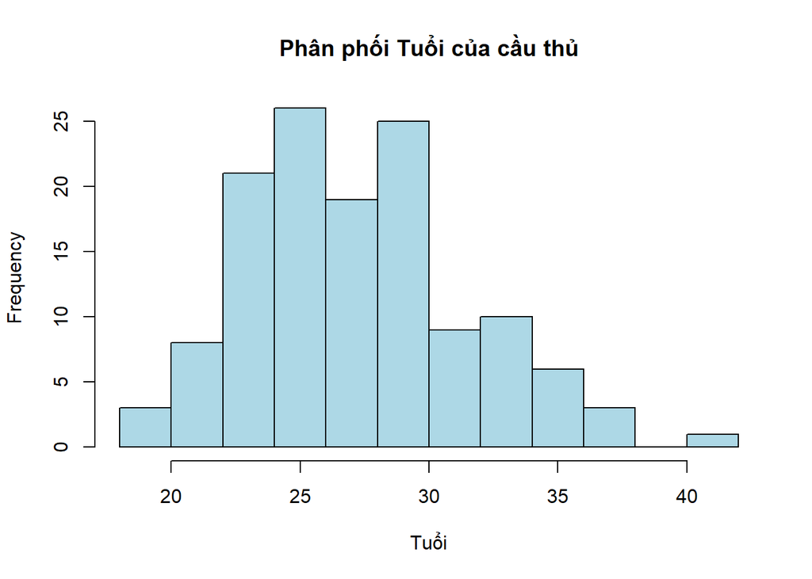

```r
# Histogram cho biến Age
hist(vnl_data$Age, main = "Phân phối Tuổi của cầu thủ", xlab = "Tuổi", col = "lightblue")
```

**Nhận xét:**

1. **Phân bố độ tuổi:**
- Tập trung chủ yếu ở khoảng 20–30 tuổi, phù hợp với thể lực đỉnh cao của vận động viên.
- Ít cầu thủ trên 35 tuổi, có thể do yêu cầu tốc độ và sức bền của môn bóng chuyền.
- Đỉnh phân phối quanh 25 tuổi, cho thấy đây là độ tuổi phổ biến nhất.
2. **Ý nghĩa:**
- Các đội tuyển có xu hướng ưu tiên cầu thủ trẻ (20–30 tuổi) để đảm bảo sự nhanh nhẹn và bền bỉ.
- Cầu thủ trên 35 tuổi thường giữ vai trò chuyên biệt (ví dụ: Libero hoặc Setter) dựa vào kinh nghiệm.

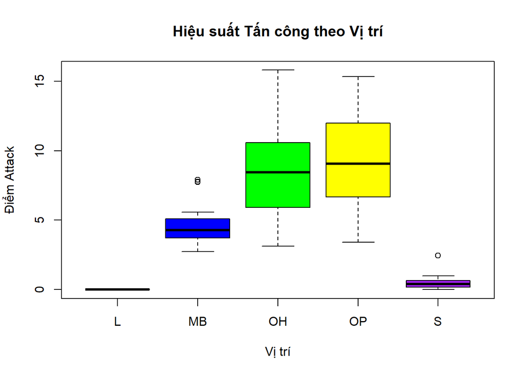

```r
# Boxplot so sánh Attack theo Position
boxplot(Attack ~ Position, data = vnl_data,
        main = "Hiệu suất Tấn công theo Vị trí",
        xlab = "Vị trí", ylab = "Điểm Attack",
        col = c("red", "blue", "green", "yellow", "purple"))
```

**Nhận xét:**

1. **Khác biệt rõ rệt giữa các vị trí:**
- OP (Opposite) và OH (Outside Hitter) có điểm Attack cao nhất (trung bình ~8–10), đúng với vai trí chủ công tấn công.
- MB (Middle Blocker) có Attack trung bình (~4–5), do tập trung vào chắn bóng.
- L (Libero) và S (Setter) gần như không tham gia tấn công (Attack ≈ 0).
2. **Độ phân tán dữ liệu:**
- OH/OP có biến động lớn về Attack, phản ánh sự đa dạng trong khả năng tấn công của từng cầu thủ.
- MB có phân phối đồng đều hơn, cho thấy vai trò ổn định trong đội hình.

**Kiểm tra missing values:**

```r
colSums(is.na(vnl_data))
```

```
##   Player  Country      Age   Attack    Block    Serve      Set      Dig
##        0        0        0        0        0        0        0        0
##  Receive Position
##        0        0
```

**Kiểm tra giá trị ngoại lai:**

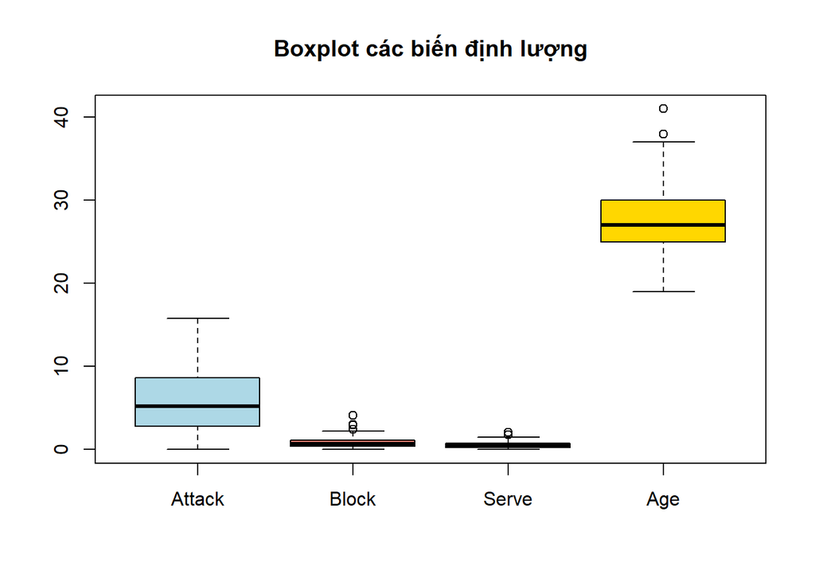

```r
# Vẽ boxplot cho các biến định lượng
boxplot(vnl_data[, c("Attack", "Block", "Serve", "Age")],
        main = "Boxplot các biến định lượng",
        col = c("lightblue", "salmon", "lightgreen", "gold"))
```

## MANOVA

### Kiểm định phân phối chuẩn đa biến

Thực hiện Shapiro-Wilk test + Q-Q plot.

```r
library(carData)
library(car)
# Chọn các biến phụ thuộc
dependent_vars <- vnl_data[, c("Attack", "Block", "Serve", "Dig", "Receive")]

# Kiểm tra Shapiro-Wilk cho từng biến
shapiro_results <- sapply(dependent_vars, shapiro.test)
print(shapiro_results)
```

```
##           Attack                        Block
## statistic 0.9446097                     0.8914108
## p.value   4.178178e-05                  2.52997e-08
## method    "Shapiro-Wilk normality test" "Shapiro-Wilk normality test"
## data.name "X[[i]]"                      "X[[i]]"
##           Serve                         Dig
## statistic 0.9114452                     0.9191755
## p.value   3.017149e-07                  8.570167e-07
## method    "Shapiro-Wilk normality test" "Shapiro-Wilk normality test"
## data.name "X[[i]]"                      "X[[i]]"
##           Receive
## statistic 0.7993852
## p.value   4.22084e-12
## method    "Shapiro-Wilk normality test"
## data.name "X[[i]]"
```

**Kết quả Shapiro-Wilk:**

- Tất cả các biến **(Attack, Block, Serve, Dig, Receive)** đều có p-value < 0.05 $\to$ Bác bỏ giả thuyết $H_0$ (dữ liệu không tuân theo phân phối chuẩn).

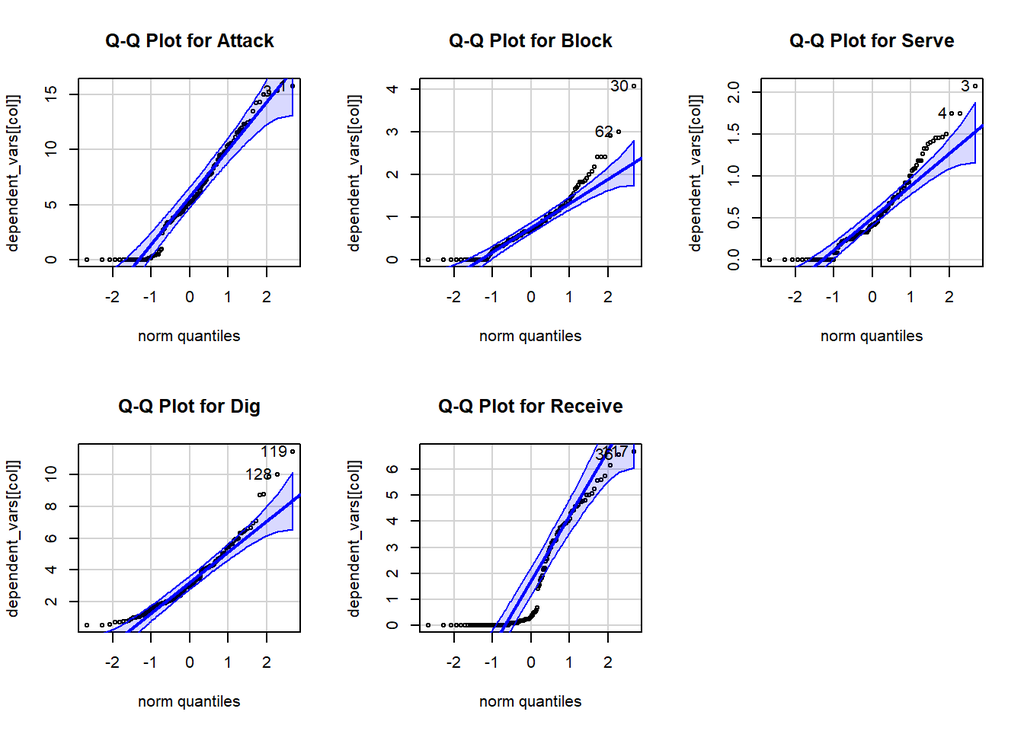

```r
# Vẽ Q-Q plot
par(mfrow = c(2, 3))  # Đặt layout cho đồ thị
for (col in colnames(dependent_vars)) {
  qqPlot(dependent_vars[[col]], main = paste("Q-Q Plot for", col))
}
```

### Kiểm định ma trận hiệp phương sai đồng nhất (Homogeneity of Covariance)

Sử dụng Box’s M test.

```r
library(broom)
library(heplots)
boxM_result <- boxM(dependent_vars, vnl_data$Position)
print(boxM_result)
```

```
##
##  Box's M-test for Homogeneity of Covariance Matrices
##
## data:  dependent_vars
## Chi-Sq (approx.) = Inf, df = 60, p-value < 2.2e-16
```

**Kết quả:** **p-value** < 2.2e-16: Bác bỏ hoàn toàn giả thuyết $H_0$ (các nhóm có ma trận hiệp phương sai khác nhau).

**Nhận xét kết quả kiểm định:**

1. **Kiểm định phân phối chuẩn**
- Kết quả kiểm định Shapiro-Wilk cho thấy tất cả các biến phụ thuộc (Attack, Block, Serve, Dig, Receive) đều vi phạm giả định phân phối chuẩn (p < 0.001), trong đó biến Receive thể hiện sự lệch chuẩn nghiêm trọng nhất (p = 4.22e-12). Điều này phù hợp với đặc thù dữ liệu thể thao, nơi hiệu suất của vận động viên thường phân bố không đối xứng.
2. **Kiểm định đồng nhất ma trận hiệp phương sai**
- Kiểm định Box’s M cho giá trị p < 2.2e-16 $(\chi^2 =\infty)$, bác bỏ mạnh mẽ giả thuyết về sự đồng nhất ma trận hiệp phương sai giữa các nhóm vị trí. Sự khác biệt này xuất phát từ bản chất khác biệt giữa các vị trí:
  - Vị trí tấn công (OH, OP) có phương sai lớn về Attack và Serve
  - Vị trí phòng thủ (L) tập trung chủ yếu ở Dig và Receive

Mặc dù vi phạm hai giả định quan trọng, tiếp theo sẽ tiến hành:

- **MANOVA** với **Pillai’s trace** do tính robust với cỡ mẫu lớn (n = 131) và vi phạm giả định vừa phải
- Kiểm định phi tham số **PERMANOVA** để kiểm chứng.

### MANOVA với Pillai’s Trace

```r
# Load thư viện cần thiết
library(car)

# Thực hiện MANOVA
manova_model <- manova(cbind(Attack, Block, Serve, Dig, Receive) ~ Position,
                      data = vnl_data)

# Sử dụng Pillai's trace (khuyến nghị khi vi phạm đồng nhất hiệp phương sai)
summary(manova_model, test = "Pillai")
```

```
##            Df Pillai approx F num Df den Df    Pr(>F)
## Position    4 2.2024   30.631     20    500 < 2.2e-16 ***
## Residuals 126
## ---
## Signif. codes:  0 '***' 0.001 '**' 0.01 '*' 0.05 '.' 0.1 ' ' 1
```

```r
# Xuất bảng ANOVA riêng lẻ nếu MANOVA có ý nghĩa
if (summary(manova_model)$stats["Position", "Pr(>F)"] < 0.05) {
  cat("\nANOVA riêng lẻ cho từng biến:\n")
  print(summary.aov(manova_model))
}
```

```
##
## ANOVA riêng lẻ cho từng biến:
##  Response Attack :
##              Df  Sum Sq Mean Sq F value    Pr(>F)
## Position      4 1619.48  404.87  69.356 < 2.2e-16 ***
## Residuals   126  735.53    5.84
## ---
## Signif. codes:  0 '***' 0.001 '**' 0.01 '*' 0.05 '.' 0.1 ' ' 1
##
##  Response Block :
##              Df Sum Sq Mean Sq F value    Pr(>F)
## Position      4 27.760  6.9401  24.221 7.037e-15 ***
## Residuals   126 36.103  0.2865
## ---
## Signif. codes:  0 '***' 0.001 '**' 0.01 '*' 0.05 '.' 0.1 ' ' 1
##
##  Response Serve :
##              Df  Sum Sq Mean Sq F value    Pr(>F)
## Position      4  8.4938 2.12344  14.587 8.114e-10 ***
## Residuals   126 18.3422 0.14557
## ---
## Signif. codes:  0 '***' 0.001 '**' 0.01 '*' 0.05 '.' 0.1 ' ' 1
##
##  Response Dig :
##              Df Sum Sq Mean Sq F value    Pr(>F)
## Position      4 342.30  85.575  49.245 < 2.2e-16 ***
## Residuals   126 218.95   1.738
## ---
## Signif. codes:  0 '***' 0.001 '**' 0.01 '*' 0.05 '.' 0.1 ' ' 1
##
##  Response Receive :
##              Df Sum Sq Mean Sq F value    Pr(>F)
## Position      4 377.91  94.478  86.975 < 2.2e-16 ***
## Residuals   126 136.87   1.086
## ---
## Signif. codes:  0 '***' 0.001 '**' 0.01 '*' 0.05 '.' 0.1 ' ' 1
```

**Nhận xét kết quả:**

- Giá trị thống kê:
  - Pillai’s trace = 2.2024 (rất lớn)
  - F = 30.631, p < 0.001 $\to$ Khác biệt rất có ý nghĩa giữa các vị trí.
- ANOVA riêng lẻ:

| Biến phụ thuộc | Giá trị F | p-value | Ý nghĩa thống kê |
| --- | --- | --- | --- |
| **Attack** | 69.356 | < 2.2e-16 *** | Khác biệt cực kỳ mạnh |
| **Block** | 24.221 | 7.037e-15 *** | Khác biệt rất mạnh |
| **Serve** | 14.587 | 8.114e-10 *** | Khác biệt mạnh |
| **Dig** | 49.245 | < 2.2e-16 *** | Khác biệt cực kỳ mạnh |
| **Receive** | 86.975 | < 2.2e-16 *** | Khác biệt cực kỳ mạnh |

$\to$ Tất cả biến đều khác biệt đáng kể (p < 0.001), đặc biệt là **Attack** và **Receive**.

### PERMANOVA (Kiểm định phi tham số)

```r
library(permute)
library(vegan)

# Tính ma trận khoảng cách Euclidean
dist_matrix <- dist(vnl_data[, c("Attack", "Block", "Serve", "Dig", "Receive")])

# Thực hiện PERMANOVA với 999 hoán vị
set.seed(123)
permanova_result <- adonis2(dist_matrix ~ Position,
                           data = vnl_data,
                           permutations = 999,
                           method = "euclidean")

# Xuất kết quả
print(permanova_result)
```

```
## Permutation test for adonis under reduced model
## Permutation: free
## Number of permutations: 999
##
## adonis2(formula = dist_matrix ~ Position, data = vnl_data, permutations = 999, method = "euclidean")
##           Df SumOfSqs      R2      F Pr(>F)
## Model      4   2376.0 0.67465 65.319  0.001 ***
## Residual 126   1145.8 0.32535
## Total    130   3521.7 1.00000
## ---
## Signif. codes:  0 '***' 0.001 '**' 0.01 '*' 0.05 '.' 0.1 ' ' 1
```

**Nhận xét kết quả:**

- Giá trị thống kê:
  - $R^2=0.67465$ $\to$ Vị trí giải thích 67.47% biến thiên dữ liệu (ảnh hưởng rất lớn).
  - $F = 65.319, p = 0.001 \to$ Khác biệt rất có ý nghĩa giữa các vị trí..

### So sánh hai phương pháp:

| Tiêu chí | MANOVA | PERMANOVA |
| --- | --- | --- |
| p-value | < 2.2e-16 (mạnh hơn) | 0.001 (vẫn rất có ý nghĩa) |
| Độ mạnh | $F = 30.631$ | $F = 65.319$ |
| Giải thích | Phân tích phương sai | Phân tích khoảng cách |
| Ưu điểm | Dễ diễn giải | Không cần giả định chuẩn |

**Nhận xét:** Cả hai đều nhất quán: Vị trí ảnh hưởng mạnh đến hiệu suất.

**Phân tích từng biến:**

### Kết luận:

Cả 2 kiểm định đều cho ta kết quả:

- **MANOVA (Pillai’s trace):**
  - $Pillai = 2.202, F = 30.631, p < 2.2e-16$
- **PERMANOVA:**
  - $R^2 = 67.47\%, F = 65.319, p = 0.001$

Vì cả hai phương pháp đều khẳng định sự khác biệt rõ rệt (độ tin cậy $> 99.9\%$). Nên ta có kết luận: **CÓ**, tồn tại khác biệt rất có ý nghĩa (p < 0.001) giữa 5 vị trí (OH, OP, MB, S, L).

Dựa trên **ANOVA riêng lẻ** và **giá trị trung bình từng nhóm**, các vị trí nổi bật như sau:

[output not shown]

- **OP (Opposite):**
  - Vượt trội **Attack** (9.33) và Serve (0.80) $\to$ Vai trò chủ công chính.
- **MB (Middle Blocker):**
  - **Block** cao nhất (1.53) $\to$ Chuyên gia chắn bóng.
- **L (Libero):**
  - **Dig** (7.09) và **Receive** (4.12) đứng đầu $\to$ Cầu thủ phòng thủ đa năng.
- **OH (Outside Hitter):**
  - Hiệu suất cân bằng, thiên về **Attack** (8.38) và **Dig** (5.85).
- **S (Setter):**
  - Không nổi bật ở kỹ năng nào $\to$ Tập trung chuyền bóng (không đo lường trong dữ liệu).

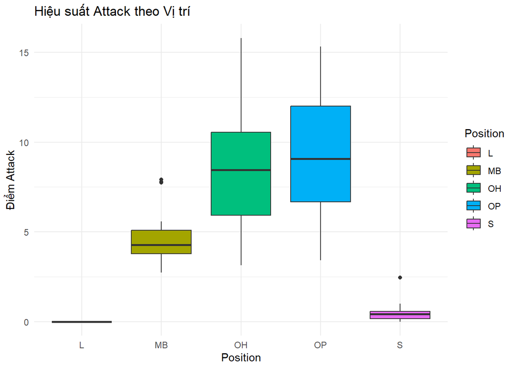

```r
library(ggplot2)
# biểu đồ Attack theo Position
ggplot(vnl_data, aes(x = Position, y = Attack, fill = Position)) +
  geom_boxplot() +
  labs(title = "Hiệu suất Attack theo Vị trí", y = "Điểm Attack") +
  theme_minimal()
```

**Từ phương pháp tham số (MANOVA) và phi tham số (PERMANOVA), ta có kết luận cuối cùng:**

1. **Khác biệt giữa các nhóm:**
- Tất cả 5 vị trí có hiệu suất khác biệt rõ rệt (p < 0.001).
- OP và OH thiên về tấn công, MB và L thiên về phòng thủ.
2. **Ứng dụng thực tế:**
- Huấn luyện viên nên phân công vị trí dựa trên thế mạnh:
  - OP/OH Tập trung vào Attack/Serve.
  - L/MB rèn luyện Dig/Block/Receive.
- Tuyển chọn cầu thủ trẻ: Đánh giá đúng tiềm năng theo từng vị trí.

## PCA

```r
# Chọn các biến định lượng cần phân tích
pca_data <- vnl_data[, c("Attack", "Block", "Serve", "Dig", "Receive")]
# Kiểm tra missing values
sum(is.na(pca_data))
```

```
## [1] 0
```

**Kiểm tra KMO và Bartlett’s test để đánh giá độ phù hợp của PCA**

1. **Kiểm định KMO (Kaiser-Meyer-Olkin)**

**Mục đích:** Đánh giá mức độ phù hợp của dữ liệu cho PCA (liệu các biến có đủ tương quan để gom nhóm thành thành phần chính không).

**Giả thuyết:**

- $H_0$ : Dữ liệu không phù hợp để phân tích PCA (các biến không đủ tương quan với nhau).
- $H_1$ : Dữ liệu phù hợp để phân tích PCA (có đủ tương quan giữa các biến).
2. **Kiểm định Bartlett’s Test of Sphericity**

**Mục đích:** Kiểm tra xem ma trận tương quan có phải là ma trận đơn vị hay không (nếu là ma trận đơn vị, PCA không có ý nghĩa).

**Giả thuyết:**

- $H_0$ : Ma trận tương quan là ma trận đơn vị (không có sự tương quan giữa các biến $\to$ không nên dùng PCA).
- $H_1$ : Ma trận tương quan không phải ma trận đơn vị (có sự tương quan đáng kể giữa các biến $\to$ có thể dùng PCA).

```r
library(psych)
KMO(pca_data)  # KMO > 0.6 là chấp nhận được
```

```
## Kaiser-Meyer-Olkin factor adequacy
## Call: KMO(r = pca_data)
## Overall MSA =  0.52
## MSA for each item =
##  Attack   Block   Serve     Dig Receive
##    0.48    0.82    0.52    0.50    0.45
```

```r
cortest.bartlett(cor(pca_data), n = nrow(pca_data))  # p < 0.05
```

```
## $chisq
## [1] 233.5285
##
## $p.value
## [1] 1.563008e-44
##
## $df
## [1] 10
```

**Kết quả:**

- Overall MSA $= 0.52 > 0.5$ nên có thể chấp nhận $H_1$, nhưng ở mức độ trung bình.
- p-value $= 1.56e-44 \approx 0$ $\to$ Bác bỏ $H_0$ (chấp nhận $H_1$). Dữ liệu có đủ tương quan để thực hiện PCA.

**Nhận xét:**

- Bartlett’s Test cho thấy PCA có thể áp dụng (do có tương quan giữa các biến).
- KMO ở mức trung bình (0.52).
- Ta thấy rằng **Attack** (MSA=0.48) và **Receive** (MSA=0.45) có MSA < 0.5 nhưng ta sẽ giữ lại 2 biến này để tiếp tục PCA.

**Chuẩn hóa dữ liệu:**

```r
pca_result <- prcomp(pca_data, scale = TRUE)
summary(pca_result)
```

```
## Importance of components:
##                           PC1    PC2    PC3    PC4     PC5
## Standard deviation     1.4465 1.3101 0.7808 0.6309 0.42874
## Proportion of Variance 0.4184 0.3433 0.1219 0.0796 0.03676
## Cumulative Proportion  0.4184 0.7617 0.8836 0.9632 1.00000
```

**Phân tích eigenvalue và variance:**

```r
eigenvalues <- pca_result$sdev^2
variance_percent <- eigenvalues / sum(eigenvalues) * 100

data.frame(
  PC = paste0("PC", 1:length(eigenvalues)),
  Eigenvalue = round(eigenvalues, 2),
  Variance_Percent = round(variance_percent, 2),
  Cumulative_Percent = round(cumsum(variance_percent), 2)
)
```

```
##    PC Eigenvalue Variance_Percent Cumulative_Percent
## 1 PC1       2.09            41.84              41.84
## 2 PC2       1.72            34.33              76.17
## 3 PC3       0.61            12.19              88.36
## 4 PC4       0.40             7.96              96.32
## 5 PC5       0.18             3.68             100.00
```

**Chọn số thành phần:**

Sử dụng tiêu chí Kaiser (Eigenvalue > 1):

```r
selected_pcs <- sum(eigenvalues > 1)
cat("Số thành phần chọn theo Kaiser:", selected_pcs)
```

```
## Số thành phần chọn theo Kaiser: 2
```

Từ kết quả trên, ta thấy các thành phần 1 và 2 có phương sai lớn hơn 1. Theo tiêu chuẩn của Kaiser, ta nên giữ lại các thành phần chính này (PC1, PC2).

**Vẽ Scree plot:**

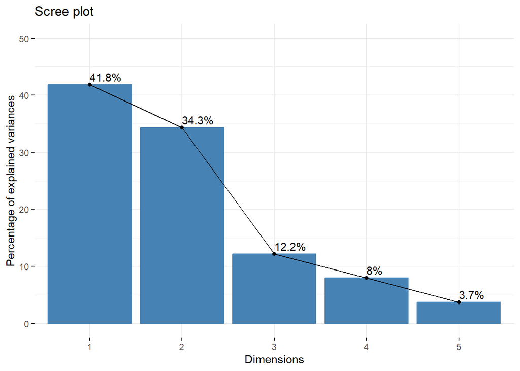

```r
library(ggplot2)
library(factoextra)
fviz_eig(pca_result, addlabels = TRUE, ylim = c(0, 50))
```

Qua đồ thị Scree-plot ta thấy sự thay đổi rõ ràng nhất về độ dốc ở thành phần chính thứ ba, PC3, đó là “khuỷa tay” của đồ thị Scree-plot. Do đó, ta có thể giữ lại hai thành phần chính đầu tiên (PC1 và PC2).

**Diễn giải các thành phần:**

```r
loadings <- pca_result$rotation[, 1:selected_pcs]
print(loadings)
```

```
##                PC1        PC2
## Attack  -0.5293290 -0.4011719
## Block   -0.4996547  0.1358328
## Serve   -0.5354991 -0.3626401
## Dig      0.3630183 -0.5365126
## Receive  0.2271881 -0.6334485
```

| Biến | PC1 | PC2 | Diễn giải | Cảnh báo MSA |
| --- | --- | --- | --- | --- |
| **Attack** | -0.529 | -0.401 | Đóng góp mạnh vào PC1 (tấn công) | MSA = 0.48 (<0.5) $\to$ Kém tin cậy |
| **Block** | -0.500 | 0.136 | Thiên về PC1 (phòng thủ tại lưới) | MSA = 0.82 (Tốt) |
| **Serve** | -0.535 | -0.363 | Đóng góp mạnh vào PC1 (tấn công) | MSA = 0.52 (Trung bình) |
| **Dig** | 0.363 | -0.537 | Đóng góp mạnh vào PC2 (phòng thủ sân sau) | MSA = 0.50 (Trung bình) |
| **Receive** | 0.227 | -0.633 | Đóng góp chính vào PC2 (đỡ bóng) | MSA = 0.45 (<0.5) $\to$ Kém tin cậy |

**Nhận xét:**

Biểu đồ Score (Phân bố cầu thủ theo PC1-PC2)

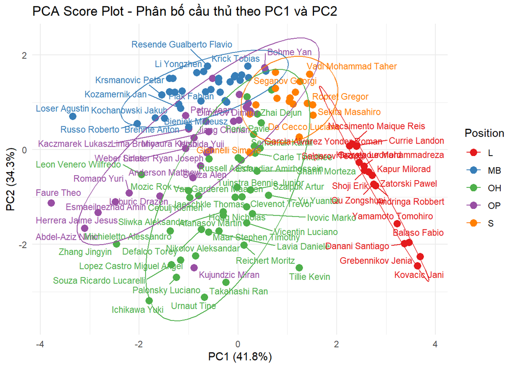

```r
library(ggplot2)
library(ggrepel)

scores <- as.data.frame(pca_result$x[, 1:2])
scores$Position <- vnl_data$Position
rownames(scores) <- vnl_data$Player

ggplot(scores, aes(PC1, PC2, color = Position)) +
  geom_point(size = 3) +
  geom_text_repel(aes(label = rownames(scores)),
                  size = 3,
                  max.overlaps = 20) +
  stat_ellipse(level = 0.95) +
  labs(title = "PCA Score Plot - Phân bố cầu thủ theo PC1 và PC2",
       x = paste0("PC1 (", round(pca_result$sdev[1]^2 / sum(pca_result$sdev^2) * 100, 1), "%)"),
       y = paste0("PC2 (", round(pca_result$sdev[2]^2 / sum(pca_result$sdev^2) * 100, 1), "%)")) +
  theme_minimal() +
  scale_color_brewer(palette = "Set1")
```

Biểu đồ Loading (Đóng góp của biến vào PC1-PC2)

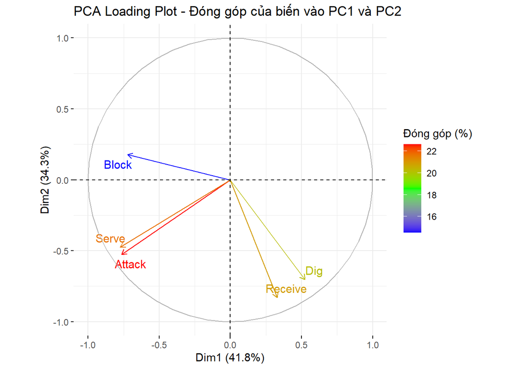

```r
library(factoextra)

fviz_pca_var(pca_result,
             axes = c(1, 2),
             col.var = "contrib",
             gradient.cols = c("blue", "green", "red"),
             repel = TRUE,
             title = "PCA Loading Plot - Đóng góp của biến vào PC1 và PC2",
             legend.title = "Đóng góp (%)")
```

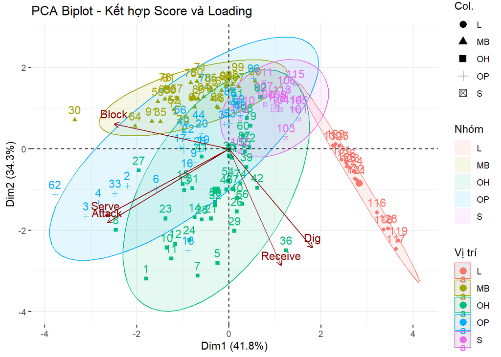

```r
fviz_pca_biplot(pca_result,
                col.ind = scores$Position,  # Màu theo vị trí
                col.var = "darkred",        # Màu cho biến
                addEllipses = TRUE,         # Vẽ vòng nhóm
                title = "PCA Biplot - Kết hợp Score và Loading",
                legend.title = list(color = "Vị trí", fill = "Nhóm"))
```

Biểu đồ biplot

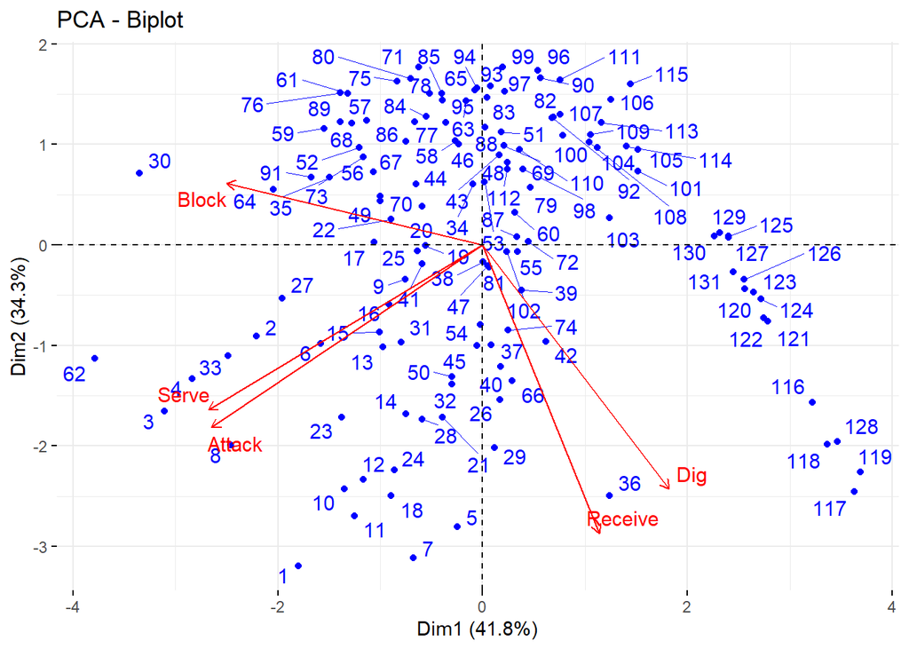

```r
# Biplot
fviz_pca_biplot(pca_result,
                col.var = "red",
                col.ind = "blue",
                repel = TRUE)
```

### Kết luận

1. Số thành phần chính cần giữ lại:

Dựa trên biểu đồ và eigenvalue > 1, 2 thành phần chính (PC1 và PC2) là đủ, giải thích 76.17% phương sai dữ liệu (PC1: 41.84%, PC2: 34.33%).

## K-means clustering

Sử dụng 2 thành phần chính (PC1 và PC2) từ PCA trước đó:

```r
pca_scores <- pca_result$x[, 1:2]  # PC1 và PC2
```

### Xác định số cụm tối ưu

Sử dụng phương pháp Elbow (Tổng bình phương nội cụm - WSS)

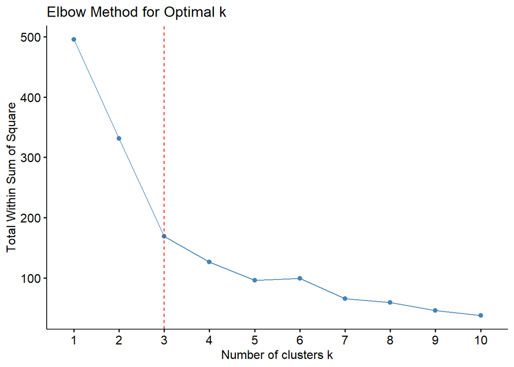

```r
library(factoextra)
fviz_nbclust(pca_scores, kmeans, method = "wss") +
  geom_vline(xintercept = 3, linetype = 2, color = "red") +
  labs(title = "Elbow Method for Optimal k")
```

Điểm gãy (elbow) xuất hiện tại $k = 3$. WSS (Tổng bình phương nội cụm) giảm mạnh từ k = 1 đến k = 3, sau đó giảm chậm nên ta chọn số cụm $k=3$.

### Thực hiện K-means clustering

```r
set.seed(123)
kmeans_result <- kmeans(pca_scores, centers = 3, nstart = 25)
vnl_data$cluster <- as.factor(kmeans_result$cluster)
```

### Trực quan hóa kết quả

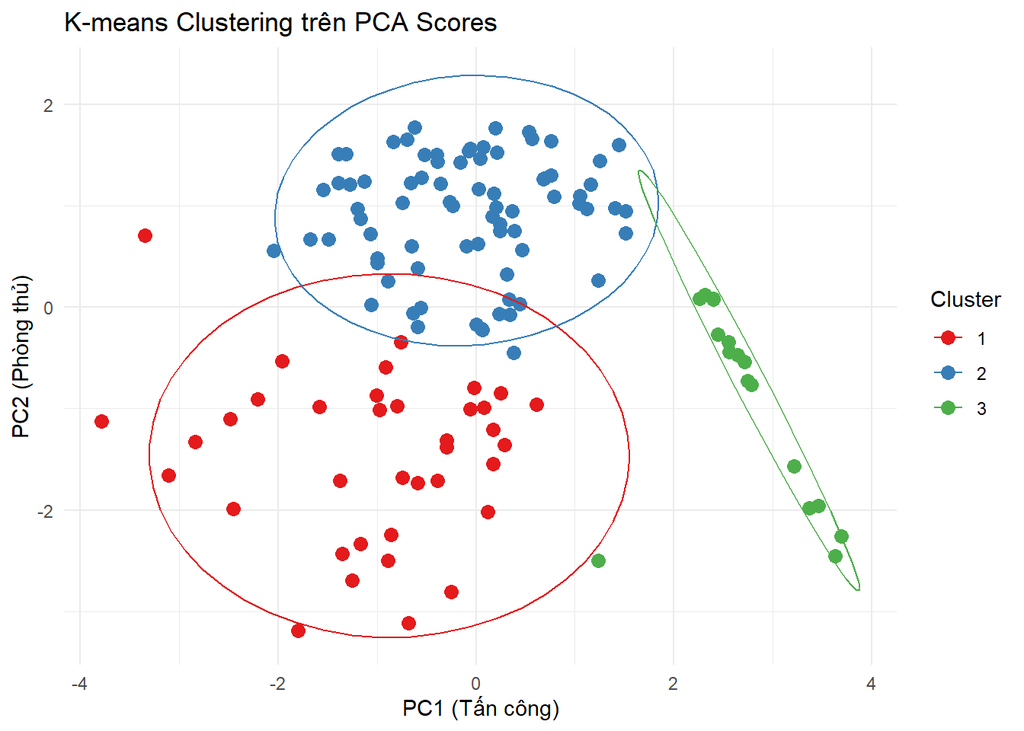

```r
library(ggplot2)
ggplot(data.frame(pca_scores), aes(PC1, PC2, color = vnl_data$cluster)) +
  geom_point(size = 3) +
  stat_ellipse(level = 0.95) +
  scale_color_brewer(palette = "Set1", name = "Cluster") +
  labs(title = "K-means Clustering trên PCA Scores",
       x = "PC1 (Tấn công)",
       y = "PC2 (Phòng thủ)") +
  theme_minimal()
```

**Phân bố các cụm trên Biểu đồ PCA**

**Diễn giải kết quả**

```r
library(dplyr)
cluster_summary <- vnl_data %>%
  group_by(cluster) %>%
  summarise(
    PC1_mean = mean(pca_scores[, 1]),
    PC2_mean = mean(pca_scores[, 2]),
    Attack = mean(Attack),
    Block = mean(Block),
    Serve = mean(Serve),
    Dig = mean(Dig),
    Receive = mean(Receive),
    n = n()
  )
print(cluster_summary)
```

```
## # A tibble: 3 × 9
##   cluster  PC1_mean  PC2_mean Attack  Block  Serve   Dig Receive     n
##   <fct>       <dbl>     <dbl>  <dbl>  <dbl>  <dbl> <dbl>   <dbl> <int>
## 1 1       -5.36e-17 -7.71e-17 10.7   1.05   1.02    4.14   3.14     37
## 2 2       -5.36e-17 -7.71e-17  4.36  0.930  0.420   2.28   0.472    77
## 3 3       -5.36e-17 -7.71e-17  0.562 0.0259 0.0129  7.05   4.00     17
```

### Kết luận

1. **Cầu thủ xuất sắc**

```r
library(dplyr)

potential_players <- vnl_data %>%
  mutate(PC1 = pca_result$x[, 1],
         PC2 = pca_result$x[, 2]) %>%
  filter(abs(PC1) > 2.5 | abs(PC2) > 2.0) %>%
  select(Player, Position, cluster, PC1, PC2, Attack, Block, Serve, Dig, Receive) %>%
  arrange(desc(abs(PC1) + abs(PC2)))

print(potential_players)
```

```
##                       Player Position cluster        PC1        PC2 Attack
## 1               Kovacic Jani        L       3  3.6294777 -2.4559562   0.00
## 2          Grebennikov Jenia        L       3  3.6892064 -2.2585065   0.00
## 3               Balaso Fabio        L       3  3.4627398 -1.9567172   0.00
## 4            Danani Santiago        L       3  3.3651622 -1.9845379   0.00
## 5              Ichikawa Yuki       OH       1 -1.7978477 -3.1926865  15.80
## 6                 Faure Theo       OP       1 -3.7847936 -1.1272764  15.25
## 7          Yamamoto Tomohiro        L       3  3.2180233 -1.5651267   0.00
## 8           Abdel-Aziz Nimir       OP       1 -3.1085083 -1.6563582  15.33
## 9        Herrera Jaime Jesus       OP       1 -2.8379247 -1.3292597  15.00
## 10             Loser Agustin       MB       1 -3.3507028  0.7107859   7.92
## 11          Palonsky Luciano       OH       1 -1.2520640 -2.6951570  11.62
## 12               Urnaut Tine       OH       1 -0.6792858 -3.1160307  12.62
## 13   Souza Ricardo Lucarelli       OH       1 -1.3523363 -2.4284420  11.85
## 14              Tillie Kevin       OH       3  1.2377552 -2.4970814   9.56
```

[output cut: 37 more lines]

**Nhận xét:**

```r
versatile_players <- vnl_data %>%
  mutate(PC1 = pca_result$x[, 1],
         PC2 = pca_result$x[, 2]) %>%
  filter(PC1 > 1.0 & PC2 > 1.0) %>%
  select(Player, Position, PC1, PC2, Attack, Block, Serve, Dig, Receive)

print(versatile_players)
```

```
##                Player Position      PC1      PC2 Attack Block Serve  Dig
## 1     Seganov Georgi         S 1.254081 1.443893   0.17  0.42  0.08 3.00
## 2       Todorovic Vuk        S 1.038868 1.023448   0.50  0.67  0.25 4.17
## 3           Herr Luke        S 1.050208 1.098447   0.17  0.67  0.25 4.00
## 4          Wang Hebin        S 1.159799 1.214384   0.42  0.00  0.33 2.50
## 5 Vadi Mohammad Taher        S 1.443964 1.602156   0.25  0.12  0.00 2.38
##   Receive
## 1    0.00
## 2    0.00
## 3    0.00
## 4    0.17
## 5    0.00
```

3. **Trực quan hóa trên Biplot**

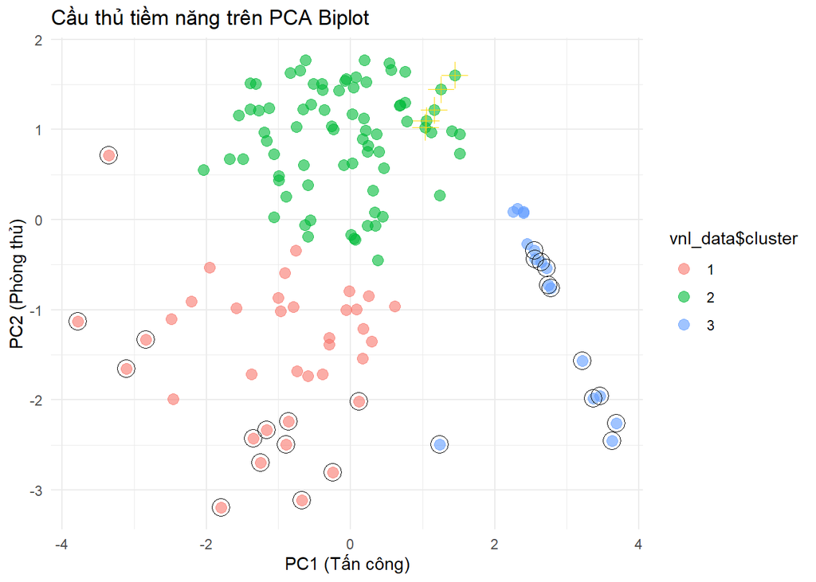

```r
library(ggplot2)
ggplot(data.frame(pca_scores), aes(PC1, PC2, color = vnl_data$cluster)) +
  geom_point(size = 3, alpha = 0.6) +
  geom_point(data = potential_players, aes(PC1, PC2), color = "black", size = 5, shape = 1) +  # Đánh dấu cầu thủ xuất sắc
  geom_point(data = versatile_players, aes(PC1, PC2), color = "gold", size = 5, shape = 3) +  # Đánh dấu cầu thủ đa năng
  labs(title = "Cầu thủ tiềm năng trên PCA Biplot",
       x = "PC1 (Tấn công)",
       y = "PC2 (Phòng thủ)") +
  theme_minimal()
```

**Nhận xét:** Cầu thủ tiềm năng

Dựa vào biểu đồ biplot: Các cầu thủ nằm ở các vị trí sau có thể là tiềm năng: